# Romance Relâmpago

```r
speed_dating <- read_csv("speed-dating.csv")
```

# Introdução

O trabalho agora é estudar dados referentes a aproximadamente 5000 encontros rápidos ([speed dating](https://en.wikipedia.org/wiki/Speed_dating)) de 4 minutos envolvendo 310 jovens americanos. Após cada encontro, os participantes respondiam a um formulário avaliando aquelas com quem eles com quem se encontraram e cada linha dos dados representa um desses encontros.

[figure not shown]

Os dados contam com 43 variáveis mas aqui lidaremos com um subconjuntos destas, os dados originais estão [aqui](https://raw.githubusercontent.com/nazareno/ciencia-de-dados-1/master/5-regressao/speed-dating/speed-dating.csv).

Foram removidas as observações em que não havia valor para qualquer uma das variáveis escolhidas.

# O quanto considerar uma pessoa atraente, divertida e ter ter interesses em comum com ela influencia o quanto você gosta de dela?

```r
dating <- speed_dating %>%
  select(like, attr, fun, int_corr) %>%
  na.omit()
```

```r
model <- lm(like ~ attr + fun + int_corr, data = dating)

date_augmented = dating %>%
  add_predictions(model) %>%
  add_residuals(model)
```

Podemos avaliar os resíduos do modelo obtido para cada uma das variáveis independentes (fatores) escolhidas:

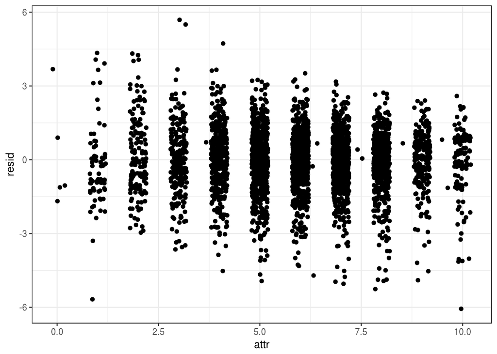

```r
date_augmented %>%
  ggplot(aes(x = attr)) +
  geom_jitter(aes(y = resid))
```

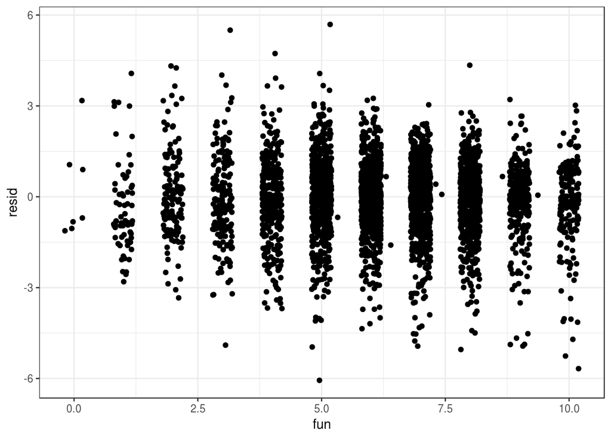

```r
date_augmented %>%
  ggplot(aes(x = fun)) +
  geom_jitter(aes(y = resid))
```

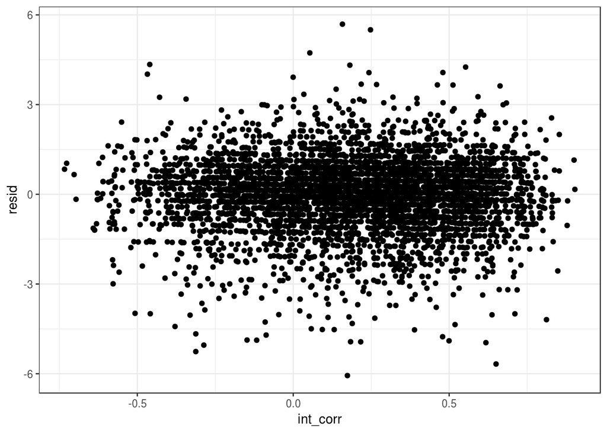

```r
date_augmented %>%
  ggplot(aes(x = int_corr)) +
  geom_jitter(aes(y = resid))
```

Com as visualizações percebemos que, para a maiora das observações, o modelo descreveu bem os dados, dado que grande parte dos pontos está entre -3 e 3, significando que grando parte dos erros está neste intervalo.

Com isso, temos indícíos de que o nosso modelo está descrevendo bem os dados e sabendo disto podemos estudar os coeficientes e o modelo obtidos.

```r
tidy(model, conf.int = TRUE) %>%
  select(-std.error, -p.value) %>%
  datatable()
```

|  | term | estimate | statistic | conf.low | conf.high |
| --- | --- | --- | --- | --- | --- |
| 1 | (Intercept) | 1.03906087457941 | 15.9209217299702 | 0.911112689823561 | 1.16700905933527 |
| 2 | attr | 0.39272023053716 | 35.826152593794 | 0.371229833123506 | 0.414210627950813 |
| 3 | fun | 0.413106749234372 | 38.3163977586572 | 0.391969962690357 | 0.434243535778387 |
| 4 | int_corr | 0.172215364661436 | 3.05981818977027 | 0.0618741862785523 | 0.28255654304432 |

Encontramos para as variáveis attr, fun e int_corr os coeficientes 0.39, 0.41 e 0.17 respectivamente, logo, quando o valor destas variáveis aumenta o valor da variável like também aumenta.

Constatamos ainda que com 95% de confiança nenhum dos intervalos contém o zero, logo a nossa estimativa é significativa.

```r
glance(model) %>%
  datatable()
```

|  | r.squared | adj.r.squared | sigma | statistic | p.value | df | logLik | AIC | BIC | deviance | df.residual |
| --- | --- | --- | --- | --- | --- | --- | --- | --- | --- | --- | --- |
| 1 | 0.58196669909533 | 0.581696535393755 | 1.18687149781699 | 2154.12616758378 | 0 | 4 | -7386.34424137582 | 14782.6884827516 | 14814.9072923183 | 6539.0180667175 | 4642 |

Nosso modelo é capaz de representar 58% da variação observada em like.

A visualização abaixo nos ajuda a compreender como se dá essa relação.

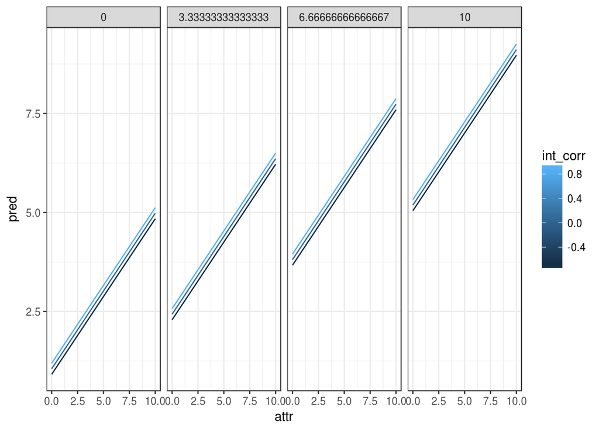

```r
plot <- dating %>%
  data_grid(attr = seq_range(attr, 10),
            fun = seq_range(fun, 4),
            int_corr = seq_range(int_corr, 3)) %>%
  add_predictions(model)

plot %>%
  ggplot(aes(x = attr, y = pred)) +
  geom_line(aes(group = int_corr, colour = int_corr)) +
  facet_grid(. ~ fun)
```

A gráfico apresenta todas as variáveis do modelo, no eixo x temos attr, a variação de cor representa a int_corr, e as facetas representam a variável fun.

# O quanto compartilhar interesses com uma pessoa e gostar dela influencia no desejo em encontra-la novamente?

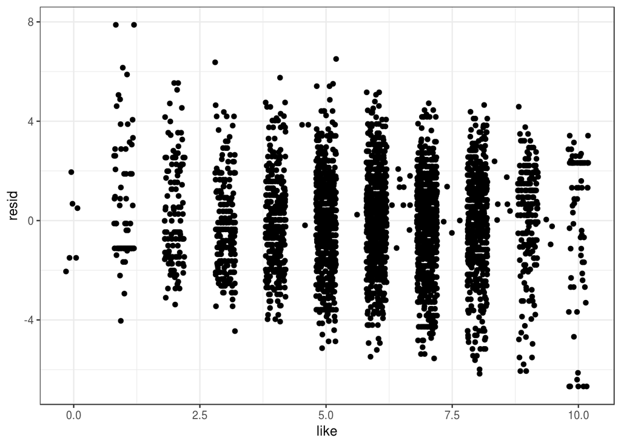

```r
dating2 <- speed_dating %>%
  select(prob, like, shar) %>%
  na.omit()

model2 <- lm(prob ~ like + shar, data = dating2) %>%
  na.omit()

model2.agument <- dating2 %>%
  add_predictions(model2) %>%
  add_residuals(model2)

model2.agument %>%
  ggplot(aes(x = like)) +
  geom_jitter(aes(y = resid))
```

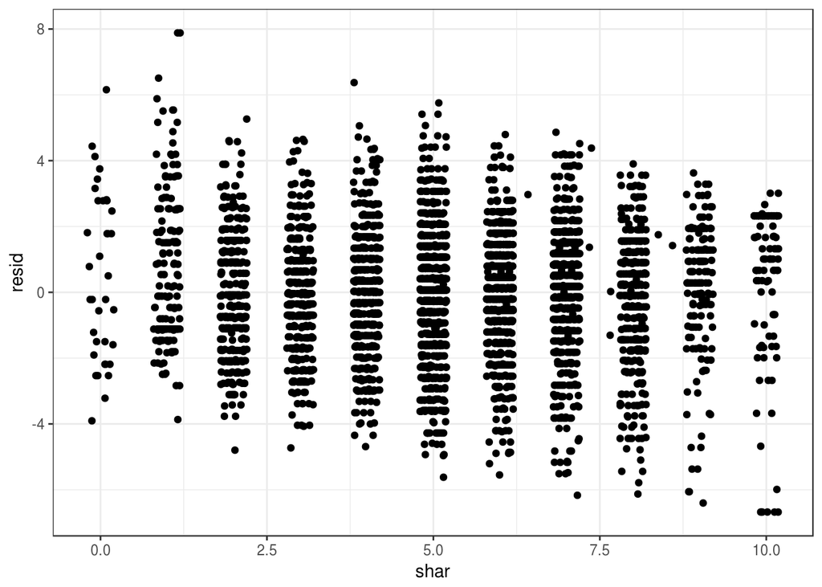

```r
model2.agument %>%
  ggplot(aes(x = shar)) +
  geom_jitter(aes(y = resid))
```

Observa-se que para todas as variáveis os resíduos, na maiora dos casos, não ultrapassam 4.

```r
tidy(model2, conf.int = TRUE) %>%
  select(-std.error, -p.value) %>%
  datatable()
```

|  | term | estimate | statistic | conf.low | conf.high |
| --- | --- | --- | --- | --- | --- |
| 1 | (Intercept) | 1.50032863126055 | 15.22102154888 | 1.30708082936007 | 1.69357643316102 |
| 2 | like | 0.343607627247958 | 16.9270501691785 | 0.303810339007843 | 0.383404915488073 |
| 3 | shar | 0.274111115241414 | 15.720904211425 | 0.239927256003642 | 0.308294974479186 |

Vemos que as variáveis like e shar possuem os coeficientes 0.34 e 0.27 respectivamente ou seja, quando o valor de uma delas aumenta de 1 prob aumenta do coeficiente correspondente.

Podemos afirmar ainda, 95% de confiança que os intervalos de confiança não contêm o zero, logo nossa estatística é significativa.

```r
glance(model2) %>%
  datatable
```

|  | r.squared | adj.r.squared | sigma | statistic | p.value | df | logLik | AIC | BIC | deviance | df.residual |
| --- | --- | --- | --- | --- | --- | --- | --- | --- | --- | --- | --- |
| 1 | 0.26355353776892 | 0.263206484770696 | 1.86623194724945 | 759.404295936673 | 1.18463470280659e-282 | 3 | -8674.52559162805 | 17357.0511832561 | 17382.4670557774 | 14781.0952138859 | 4244 |

No entanto ao analizar o R quadrado vemos que o modelo escolhido não é representativo, já que ele é capaz de explicar apenas 26% da variação sobre a variável prob.

Mesmo assim, veremos como se dá essa influência:

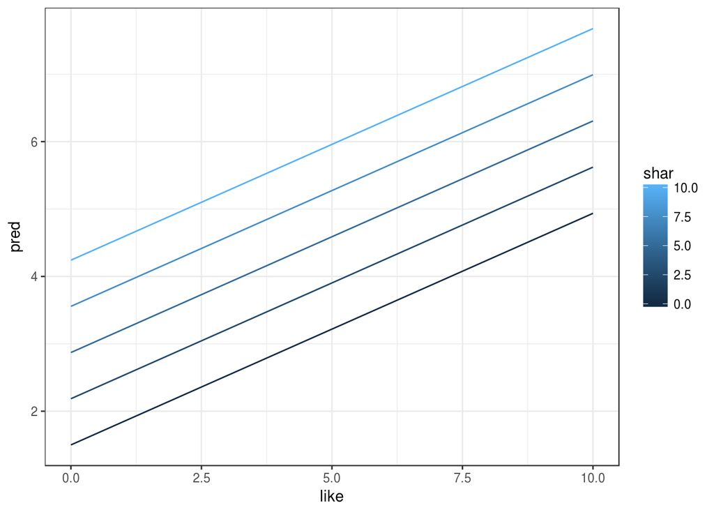

```r
plot <- dating2 %>%
  data_grid(like = seq_range(like, 10),
            shar = seq_range(shar, 5)) %>%
  add_predictions(model2)

plot %>%
  ggplot(aes(x = like, y = pred)) +
  geom_line(aes(group = shar, colour = shar))
```